# Reproducible Research: Peer Assessment 1

## Loading and preprocessing the data

1. Load the data

```r
data <- read.csv( "activity.csv", header = TRUE )
```

2. Reformat the date column as date data type

```r
data$date <- as.Date( data$date )
```

## What is mean total number of steps taken per day?

1. Create a new table containing total steps by date

```r
library( 'plyr' )
dailyTotal <- ddply( data, .(date), summarize, steps = sum( steps ) )
```

2. Plot a histogram of the total number of steps taken each day

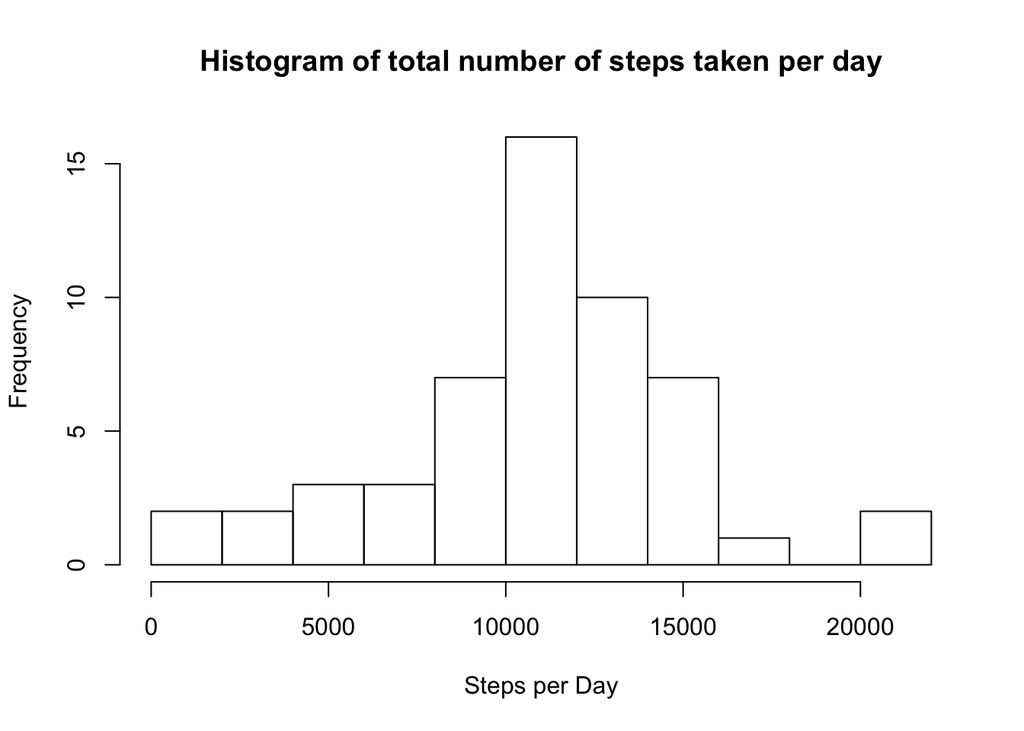

```r
hist( dailyTotal$steps, breaks=12, main="Histogram of total number of steps taken per day", xlab="Steps per Day" )
```

3. Compute the mean and median total number of steps per day.

```r
meanSteps <- mean(dailyTotal$steps, na.rm=TRUE)
medianSteps <- median(dailyTotal$steps, na.rm=TRUE)
```

The mean is 10766.19. The median is 10765.00.

## What is the average daily activity pattern?

```r
dailyAverage <- ddply( data[ c(1,3)], .(interval), colwise(mean), na.rm=TRUE )
```

2. Plot a time series of the 5-minute interval against the average number of steps taken

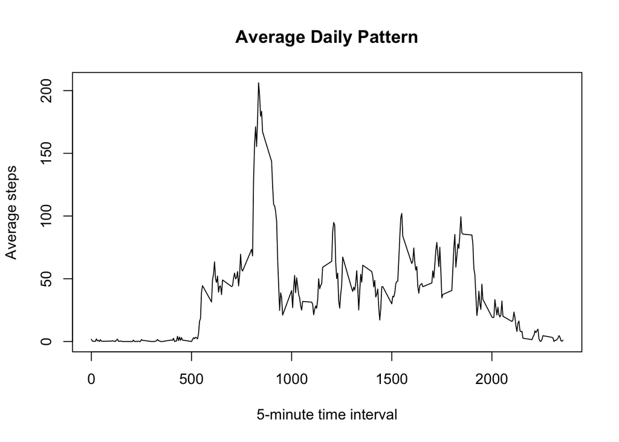

```r
plot( dailyAverage$interval, dailyAverage$steps, type="l", main="Average Daily Pattern", xlab="5-minute time interval", ylab="Average steps")
```

3. Identify the 5-minute interval with the highest average number of steps.

```r
maxStepsInterval <- dailyAverage$interval[ which.max( dailyAverage$steps )]
maxSteps <- dailyAverage$steps[ which.max( dailyAverage$steps )]
```

The 5-minute interval with the highest number of steps is interval 835 with an average of 206.17 steps.

## Imputing missing values

1. Determine the total number of rows with missing (NA) data.

```r
summary(data)
```

```
##      steps            date               interval
##  Min.   :  0.0   Min.   :2012-10-01   Min.   :   0
##  1st Qu.:  0.0   1st Qu.:2012-10-16   1st Qu.: 589
##  Median :  0.0   Median :2012-10-31   Median :1178
##  Mean   : 37.4   Mean   :2012-10-31   Mean   :1178
##  3rd Qu.: 12.0   3rd Qu.:2012-11-15   3rd Qu.:1766
##  Max.   :806.0   Max.   :2012-11-30   Max.   :2355
##  NA's   :2304
```

“Steps”" is the only column with missing data. Retrieve the number of rows.

```r
rowsWithNA <- summary( data$steps )[ c("NA's" ) ]
```

There are 2304 rows with missing data.

2. Create a new dataset based on the original with the missing data filled with the daily average for the 5-minute interval

```r
test <- function(s,t) {
    if ( is.na(s) )
      return( dailyAverage$steps[ dailyAverage$interval == t ] )
    else
      return( s )
  }

newData <- ddply( data, .(steps,interval,date), transform, steps = test( steps, interval ),
                   interval=interval, date=date )
summary(newData)
```

```
##      steps            date               interval
##  Min.   :  0.0   Min.   :2012-10-01   Min.   :   0
##  1st Qu.:  0.0   1st Qu.:2012-10-16   1st Qu.: 589
##  Median :  0.0   Median :2012-10-31   Median :1178
##  Mean   : 37.4   Mean   :2012-10-31   Mean   :1178
##  3rd Qu.: 27.0   3rd Qu.:2012-11-15   3rd Qu.:1766
##  Max.   :806.0   Max.   :2012-11-30   Max.   :2355
```

3. Plot a histogram of the new dataset

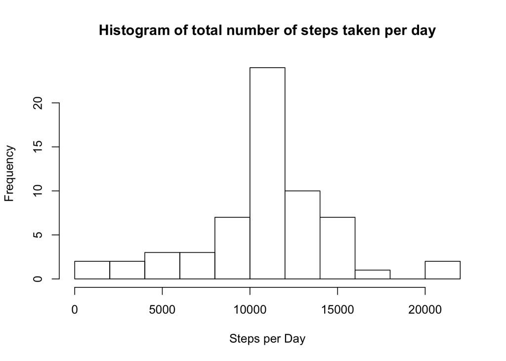

```r
#Create a new table containing total steps by date
newDailyTotal <- ddply( newData, .(date), summarize, steps = sum( steps ) )

#Plot a histogram of the total number of steps taken each day
hist( newDailyTotal$steps, breaks=12, main="Histogram of total number of steps taken per day", xlab="Steps per Day" )
```

```r
#Compute the mean and median total number of steps per day.
newMeanSteps <- mean(newDailyTotal$steps, na.rm=TRUE)
newMedianSteps <- median(newDailyTotal$steps, na.rm=TRUE)
```

The mean is 10766.19. The median is 10766.19.

The mean does not differ from the original mean of 10766.19. There is a slight change from the original median of 10765.00.

Imputing missing data has altered the data by increasing the frequency of occurence as evident in the new histogram.

## Are there differences in activity patterns between weekdays and weekends?

1. Introduce a two-level factor variable indicating “weekday” and “weekend”

```r
newData$dayType <- "weekday"
newData$dayType[ weekdays( newData$date ) %in% c( "Saturday", "Sunday" ) ] <- "weekend"
newData$dayType <- as.factor( newData$dayType )
```

2. Build a two-panel time series plot comparing “weekend” and “weekday” 5-minute interval against average number of steps.

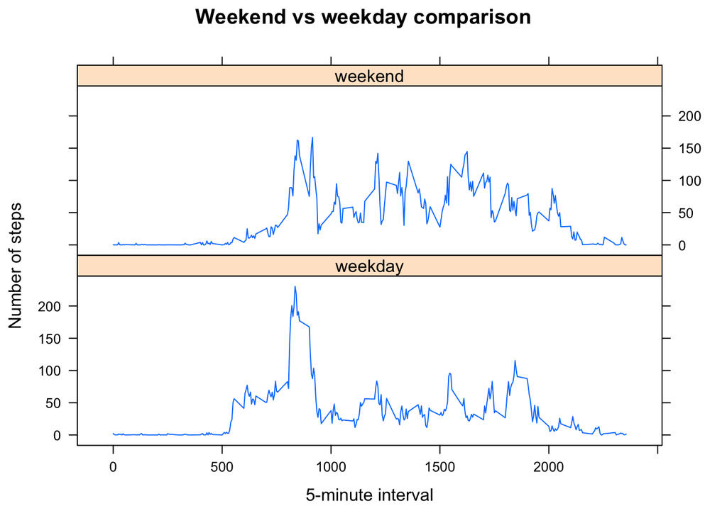

```r
# Create a new table containing average steps by day type
dayTypeAverage <- ddply( newData[ c(1,3,4)], .(interval,dayType), colwise(mean), na.rm=TRUE )

# Build lattice plot
library( lattice )
xyplot( steps ~ interval | dayType,
        data = dayTypeAverage,
        type = "l",
        layout = c( 1, 2 ),
        main = "Weekend vs weekday comparison",
        ylab = "Number of steps",
        xlab = "5-minute interval"
        )
```